# Lecture 2 – Heart I: anatomy and circuits

Jeffrey A. Walker

19 July, 2021

# The circulatory system is composed of a pulmonary circuit and a systemic circuit

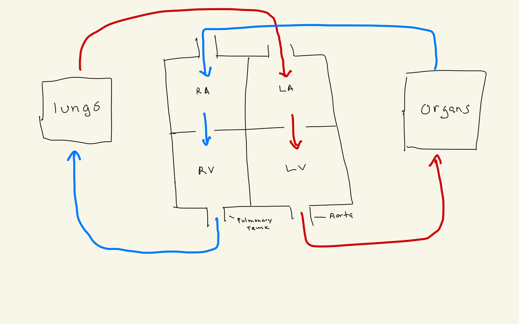

1. A circuit in the circulatory system is the set of blood vessels that carry blood from the heart to organs and then back to the heart. This can be represented as heart -> artery -> organ -> vein -> heart. Within each organ, arties branch into little vessels call **arterioles** that lead to the **Capillary networks** and little vessels called **venules** drain the capillary networks and merge to form veins in the organ. So we can expand a circuit to include this: heart -> artery -> arterioles -> capillary -> venules -> vein -> heart.
2. All exchange between stuff in the blood and cells occurs in the capillaries. This exchange is not direct. The path is plasma <-> interstitial fluid <-> cell. Please understand this.
3. Our circulatory system is composed of a
- **pulmonary cicuit** blood from the right side of the heart exits the right **ventricle** via the **pulmonary trunk**, travels to the lungs, then back to the **left atrium** via the **pulmonary veins**. **gas exchange** occurs in the **pulomonary capillaries** – O2 diffuses from alveolar air into capillary blood and CO2 diffuses from capillary blood to alveolar air. This will be covered in more depth in the respiratory system component of this unit.
- **systemic circuit**. blood from the left side of the heart exits the left **ventricle** via the **aorta**, travels to all organs, then back to the **right atrium** via the **vena cava**. **gas exchange** occurs in the **systemic capillaries** – O2 diffuses from capillary blood into the sytemic cells and CO2 diffuses from the cells into into capillary blood. Again, covered in more depth in the respiratory system component of this unit.
4. Given the gas exchange directions above, the lungs are said to **oxygenate** the blood. The systemic organs **doxygenate** the blood. The pulmonary veins carry oxygenated blood from the lungs to the heart. The aorta and its branches carry oxygenated blood to the organs. The veins carry dexoygenated blood from the organs to the heart. The pulmonary trunk and its two branches carry deoxygenated blood from the heart to the lungs.
5. A major misconception is the meaning of **deoxygenated**. It does not mean “without O2”. It simply means “less O2” – dexoygenated blood has less O2 than oxygenated blood because there has been net transport, by diffusion, from the blood to the cells. Deoxygenated blood in a resting person is still about 70% of the maximum O2 that can be carried. This is a lot of O2.
6. Repeat this mantra “dexoygenated means less O2 not absence of O2”
7. All of this can be represented with a drawing to re-inforce learning. When learning blood flow through the heart and the pulmonary and systemic circuits, it is much easier to draw something like that above than to try to recreate the professional drawings in textbook. Why? Because the above image throws away most extraneous information while preserving the information you are trying to learn. The aort and pulmonary trunk exit the superior surface of the heart but in my drawing it looks like these exit the inferior surface. The drawing is not meant to convey the information of the anatomical position of the aorta and pulmonary trunk but simply that these tubes exit the left and right ventricles. If I were to draw these pipes anatomically correctly, it would be a mess, because these pipes would get in the way of the depiction of the chambers of the heart.
8. And, importantly, we can use this information and drawing to define **artery** and **vein**. Arteries are blood vessels that transport blood away from the heart. Veins are blood vessels that return blood to the heart. Do not fall for the miscoconception that arteries carry oxygenated blood while veins carry deoxygenated blood. This is true for the systemic but not the pulmonary circuite and only in **adult circulation** (or post-natal circulation). Huh? There is **fetal circulation**?

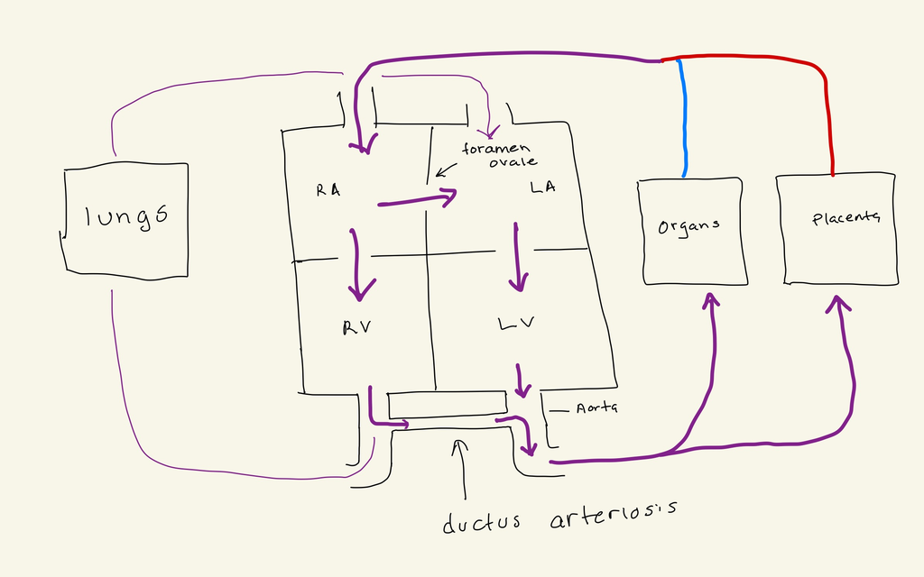

9. Yes! What is this fetal circulation? The lungs are not functioning as gas exchangers because a fetus doesn’t “breathe” (or **ventillate the lungs**). Instead, a fetus gets oxygenated blood from the placenta, which is the structure surrounding the fetus and intimately connected to the uterine wall of the mother. This oxygenated blood returns to the heart via and mixes with deoxygenated blood from systemic veins. Because the lung isn’t functioning as a gas exchanger, the blood is mostly **shunted** from the right (pulmonary) side to the left (systemic) side via to **shunts** (a little volume does move from pulmonary trunk to the lungs)
- foramen ovale – this is a gap in the wall between the right and left atrium. Mixed blood moves from R to L and then pumped to systemic organs
- ductus arteriosus – this is a small artery that connects the pulmonary trunk and aorta. Mixed blood moves from PT to aorta and then to systemic organs.
10. These shunts work because the path through the shunt provides less resistance to flow than the alternative path. Once a baby is born and takes a breath and expands the lungs, the resistance to blood flow in pulmonary vessels decreases a bunch and suddenly the path to the lungs has the least resistance. After the lungs expand, blood on the R side of the heart tends to move past the foramen ovale and ductus arteriosus to the lungs and the foramen ovale and ductus arteriosus close up soon after birth.
- What is the fate of the foramen ovalis? A thin wall grows over the foramen ovale leaving a little depression in the wall called the **fossa ovalis**. If you get the chance to handle a sheep’s or human’s heart, you can place your fingers on either side of the wall between the atria and feel around and feel the spot where the wall is very thin. Your fingers are in the fossa ovalis.
- What is the fate of the ductus arteriosis? Fibroblasts lay down DCT matrix and the duct scars over becoming the **ligamentum arteriosum**. It’s pretty easy to dissect this out in an intact human heart even though its buried in a bunch of fat. It’s pretty hard to dissect this out in a sheep’s heart because the vessels are usually cut right where it occurs.